# 10 Design of Experiments and Statistics

Sensitivity and efficiency

Authors

Affiliations

Pedro J. Aphalo

University of Helsinki

Harri Högmander

University of Jyväskylä

Published

July 15, 2024

Modified

August 14, 2026

Abstract

This chapter discusses design of experiments and data analysis from the perspective of basic and applied research in plant photobiology, providing geenral guidelines and specific example cases.

## 10.1 Prediction and attribution vs. prediction and estimation

Data analysis can have two different aims *prediction and attribution* or *prediction and estimation*. In the first case, we test a hypotheses formulated *a priori*, assigning a significance to predictors. In the second case, we aim at estimating curves or surfaces that describe a relationship and possibly predict new yet unobserved cases. Traditional statistics are useful in both cases. Newer methods that rely on big data can be called “pure prediction algorithms”, e.g., neural nets, deep learning, random forests, and similar methods. These methods taken broadly are unsuitable for attribution, i.e., for hypothesis testing in scientific research (Efron 2020).

The guidelines given here for good experimental design have been formulated with particular consideration given to experiments based on the manipulation of the UV, VIS and NIR radiation environemnt. Nevertheless most of the principles behind these guidelines can be generally applied to the design of experiments.

Experiments can be designed to test attribution (hypothesis testing), to estimate relationships between explanatory and response variables. In this second case we may be content to estimate the likely value of parameters given a model, or do model selection, estimating not only parameter values and their confidence, but also selecting based on data the formulation of the model.

In the case when attribution is the aim, we should be careful not to let our knowledge of the data influence the tested hypothesis[^35]. In the second case, model choice can to some extent depend on the data, but we should be aware that this *a posteriori* choice of a functional relationship, could make the $P$-values less strict and thus invalid for assigning attribution.

Fitting models, for attribution or estimation, is especially useful when the parameters of the model have a biological or physical interpretation. In the case of estimation, it is important to also obtain estimates of the reliability of the estimates of the parameters values. In other words, we need to present not only the fitted values, but also their confidence intervals, or at least their standard deviations.

All estimates of $P$-values are based on a comparison of the variation between differently treated experimental units, and the variation among equally treated experimental units[^36]. If we assign treatments objectively by randomization, we can expect that in the absence of a treatment effect, on average, there will not be more variation among differently treated units than between equally treated units. The quality of the estimates obtained for the magnitude of these sources of variation will depend on the number of replicates measured, on proper randomization, and on an adequate design being used to control known error sources. The remaining unaccounted variation among equally treated units is called *experimental error*.

When using tests of significance one should be aware that the $P$-value will depend on both the size of the treatment effect and on the standard deviation of the estimate (e.g., standard error of the mean) which strongly depends on the number of replicates. In an experiment with hundreds of replicates one is very likely to detect treatment effects that are statistically-significant, even if these effects are too small to be of any biological significance. On the contrary, in an experiment with few replicates, one risks biologically-significant effects remaining undetected. One should never forget that a large $P$-value indicates only that we have been unable to demonstrate an effect of a treatment, rather than demonstrating that such an effect did not exist. Strictly speaking it is impossible to demonstrate that there is no effect. However, what we can do is to estimate the size of the smallest effect that our experiment could have detected. This can be done by means of ‘statistical-power analysis’ (see Cohen 1977; Quinn and Keough 2002, chap. 7).

John W. Tukey (1991) has written:

> Statisticians classically asked the wrong question—and were willing to answer with a lie, one that was often a downright lie. They asked “Are the effects of A and B different?” and they were willing to answer “no.”

> All we know about the world teaches us that the effects of A and B are always different—in some decimal place—for any A and B. Thus asking “Are the effects different?” is foolish.

> What we should be answering first is “Can we tell the direction in which the effects of A differ from the effects of B?” In other words, can we be confident about the direction from A to B? Is it “up,” “down” or “uncertain”?

> The third answer to this first question is that we are “uncertain about the direction”—it is not, and never should be, that we “accept the null hypothesis.”

## 10.2 Planning of experiments

It is very important to properly design and plan an experiment in advance of its execution. From a well planned experiment one gets more interpretable and reliable results, usually with less effort and expense, and even sometimes faster. Often, badly planned experiments can yield unreliable data or results that do not answer the intended objective of a study. There are too many examples in the scientific literature of badly designed experiments or invalid statistical analyzes leading to erroneous conclusions, and manuscripts submitted for publication are frequently rejected by journals on the basis of a poorly thought through design.

## 10.3 Definitions

Quoting Cox and Reid (2000):

**Experimental units:**

are the patients, plots, animals, plants, raw material, etc. of the investigation. Formally they correspond to the smallest subdivision of the experimental material such that any two different experimental units might receive different treatments (e.g. filter frames, lamp frames, growth chambers).

**Treatments:**

are clearly defined procedures one of which is to be applied to each experimental unit.

**Response:**

the response measurement specifies the criterion in terms of which the comparison of treatments is to be effected. In many applications there will be several such measures.

See Box [ex:stats:definifitions] for examples.

- We have 100 plants, we apply pure water to 50 plants, and a fertilizer dissolved in water to the remaining 50 plants. After two weeks we measure the dry weight of all plants.
- The plants are in individual pots, so each plant might receive fertilizer or not: the plants are the experimental units.
- The manipulation procedures applied to the plants are: 1) apply water, or 2) apply water + fertilizer. These are the two treatments, which could be called 1) control, 2) fertilization.
- The response is the criterion we will use to compare the treatments: the dry weight of the plants two weeks after the treatments are applied.

## 10.4 Experimental design

As discussed by Cox and Reid (2000), the most basic requirement for a good experiment is that the questions it addresses should be interesting and fruitful. Usually this means examining one or more well-formulated research hypothesis. In most cases the more specific the research question asked, the greater the chance of obtaining a meaningful result. Quoting J. W. Tukey “An approximate answer to the right problem is worth a good deal more than an exact answer to an approximate problem.”

Once the research hypothesis to test has been chosen:

the experimental units must be defined and chosen,

the treatments must be clearly defined,

the variables to be measured in each unit must be specified, and

the size of the experiment, in particular the number of experimental units, has to be decided.

Questions detailing the steps:

1. What is the purpose of the experiment? To which objective questions do we want to find answers?
2. What treatment is to be applied? At what levels? Do we include an untreated control? Is there any structure within the treatments?
3. What is the response to be observed and recorded? What is the nature of the observations?
4. Are there other variables which could affect the response?
5. How big a difference in response is practically important? How big a difference in response should be detectable?
6. How many experimental units are appropriate and practical to use?
7. How do we organize the experiment? What, where, when, how, who...?
8. How will the data obtained be analyzed?

In addition to performing these steps, keep notes in a logbook of the experimental plan, and everything done during the experiment. This will allow you to go back and check if the design was sound and how faithfully it was followed. By noting any changes that were made we may remember something important to assist in the interpretation of the results, or an improvement to make to future experimental designs. If necessary, such notes will also allow for any future repetition of the whole experiment. See examples in Box [ex:stats:UVexp:design].

**NoteRequirements for a good experiment**

Following Cox (1958, chap. 1):

- **Precision.** Random errors of estimation should be suitably small, and this should be achieved with as few experimental units as possible (a sort of cost/benefit analysis).
- **Absence of systematic error.** Experimental units receiving different treatments should differ in no systematic way from one another (to avoid bias confounded with effects of interest).
- **Range of validity.** The conclusions should have as wide a range of validity as needed for the problem under study.
- **Simplicity.** The experiment should be as simple as possible in design and data analysis.
- **Assessment of uncertainty.** A proper statistical analysis of the results should be possible *without making artificial assumptions*. (The fewer and more plausible the assumptions are, the more credible results and conclusions will be.)

In practice we almost never have too many replicates in experiments, as the responses under study tend to be small compared to the random variation. For experiments, more frequently the problem at hand is how to make the most efficient use of the limited number of true replicates that we can afford. Good experimental design helps with this and helps us to assess the feasibility of experiments given a limited amount of resources. Fulfilling the requirements listed above will ensure that conclusions derived from experiments are valid.

## 10.5 The principles of experimental design

We will consider three ‘principles’ on which the design of experiments should be based: replication, randomization, and grouping into blocks. Each of these principles ensures that one aspect of the design of an experiment is correct and increases the likelihood that it will yield data that can be statistically analyzed without need for unrealistic assumptions.

**NotePrinciples of experimental design**

1. Replication $\rightarrow$ control of random variation $\rightarrow$ precision.
2. Randomisation $\rightarrow$ elimination of systematic error.
3. Use of blocks or covariates $\rightarrow$ reduction of error variation caused by experimental unit heterogeneity.

In the sections below we discuss each of these principles in turn and give examples of their application.

### 10.5.1 Replication

When an experiment is done several times, either simultaneously or sequentially, each time or repetition is a *replicate*. Replication serves several very important roles.

1. Replication allows for estimation of the random variation accompanying the results. This random variation is called *experimental error*.
2. Replication increases the precision with which the treatment effect is estimated, because each repetition gives additional information about the experiment. This can be appreciated from the equation relating the variance of the original population to that of the mean: $\sigma^2_{\overline{x}} = \frac{\sigma^2}{n}$, where $\overline{x}$ is the mean, $n$ the number of replicates, and where $\sigma^2$ is the variance (of individual measurements) and $\sigma^2_{\overline{x}}$ is the variance of the mean. The standard error of the mean is $\sigma_{\overline{x}} = \sqrt{\sigma^2_{\overline{x}}} = \frac{\sigma}{\sqrt{n}}$ frequently abbreviated to s.e. or S.E.M.

### 10.5.2 Randomization

Which treatment is applied to each experimental unit should be decided at random (if appropriate after forming blocks). The idea is to be objective. One should avoid any subjective or approximately random procedures, which would invalidate any statistical test based on the data collected from such an experiment. In addition to assigning treatments at random, other possible sources of bias should be avoided by randomization:

1. The order in which measurements are done in the different experimental units should be randomized. Never measure all the experimental units receiving one level of treatment together and then all those receiving another level of treatment together. If the design includes blocks, then do the measurements by block, with the order of the different levels of treatment assigned at random within blocks. Be particularly careful if using more than one machine of the same type to make sure that the machines have been cross-calibrated. Likewise, if more than one person is working on an experiment, test that both people use the same criteria for taking measurements by comparing their readings when measuring a subsample of the same experimental units.
2. If several treatments are applied to each experimental unit in a sequential design, the order in which they are applied should be randomized.
3. Everything that can be randomized, should be randomized to avoid bias, and to ensure that the assumptions behind statistical tests of significance are fulfilled.

Randomization is of fundamental importance because:

1. It allows the organization of an experiment to be objective.
2. It prevents systematic errors from known and unknown sources of variation, because when randomized, these sources of variation should affect all treatments equally ‘on average’. Randomization guarantees that the estimators obtained for the treatment effect and of the error variance are unbiased. This in turn allows valid conclusions to be derived from statistical tests.

### 10.5.3 Blocks and covariates

In designs with blocks we arrange the experimental units into homogeneous groups (according to some important characteristics). Each of these groups is called a *block*. Treatments are randomized within the blocks, normally with all treatments present in each block at least once. If blocking is successful it decreases the error variance because the systematic variation between the blocks can be separately accounted for in the analysis. If blocking is not successful, the estimator of error variance is not significantly reduced, but has fewer degrees of freedom[^37].

Every effort should be made to use and retain a balanced design (i.e. blocks of the same size, and an equal number of replicates for all treatments) since this makes analysis and interpretation of results much simpler. There are sometimes advantages to the adoption of more complex (but still balanced) designs that use the same principles as blocking, but allocate treatments to groups based on more than one criterion. Examples of these are Latin square and Greco-Latin square designs. See Box [ex:stats:block].

**TipExamples**

If the experimental units belong to two, or more, statistical populations, then the best option is to use a design that acknowledges this. Such populations could be distinct soil series, cultivars or even years.

For example if we have three different cultivars of a crop that are important in a certain region for which we want the conclusions from our experiment to be applicable, we need to include several experimental units for each of the cultivars. In this case, structure should be added by classifying the units into three blocks one for each cultivar. In this way the sensitivity of our test will not be affected by the additional variation due to cultivars, but the results will be applicable to the three of them, instead of just to one.

If we suspect that the cultivars may respond to UV differently, the appropriate design would be a factorial one, which would allow to assess this difference through the interaction term.

Even if it is impossible to group the experimental units into homogeneous blocks, it may be possible to measure some relevant property of the experimental units before applying the treatments. Afterwards, this measured variable can be included as a covariate in an analysis of covariance (ANCOVA), or linear mixed effects (LME) or non-linear mixed effects (NLME) model. This may improve the performance of the statistical tests, by accounting for some of the random variability among experimental units. In any case, one should be careful with interpretation of ANCOVA results (Cochran 1957; Smith 1957). Including a covariate in a model does not lessen the requirement for proper randomization.

The flowchart below summarizes the designs most suitable for different *simple* cases based on the characteristics of the experimental units.

[figure not shown]

Choice of statistical design based on the type of variation among the available experimental units.

## 10.6 Experimental units and subsamples

It is very important to understand the difference between experimental units and subsamples. This is crucial because correct statistical analysis is only possible if we correctly identify the experimental units in our experiments. An *experimental unit* is the unit or ‘thing’ to which the treatment is assigned (at random) (e.g. a tray of plants). An experimental unit is not necessarily the unit that is measured, which can be smaller (e.g. a leaf from a treated plant). A measured object (= measurement unit) which is smaller than an experimental unit is called a subsample (or subunit).

In a simple design the experimental units are usually easy to identify. The same is true for non-hierarchical factorial designs (i.e. when the factors are not nested). However, in hierarchical designs, like split-plot designs, the experimental units for one factor may be nested within the larger experimental units used for another factor. In such a case, the error terms in an ANOVA will be different for the different factors, and will also have a different number of degrees of freedom. Another common situation occurs when treatments are applied to experimental units and the same units are measured or sampled repeatedly in time. In this case it is not appropriate to apply a factorial design, with time as one factor, in an ANOVA since this would assume that all observations are independent. Instead one should use a design that takes into account the correlation among the repeated measurements. See examples, and the flowchart for a summary of how the relationship between experimental and measurement units affects the data analysis.

1. In an experiment we grow three plants per pot. We have nine pots. The treatments are three different watering regimes, which are assigned to the pots. We measure photosynthesis on individual plants. We get three numbers per pot. The pots are the experimental units. The photosynthesis measurements from each plant are subsamples. The subsamples are not independent observations. The (random) assignment of the treatments was not done on the plants, so the plants are not experimental units. The treatments were assigned to the pots.

   $n = 3, N = 9$

   $n$ is the number of true replicates. $N$ is the number of experimental units in the whole experiment.
2. In an experiment we grow three plants per pot. We have nine pots. The treatments are three different foliar fertilizers, which are assigned (at random) to the plants within each pot. We measure photosynthesis on individual plants. We get three numbers per pot. The plants are the experimental units. The photosynthesis measurements from the plants are replicates. The three plants in each pot are not independent of each other. To account for this non-independence, the pots are treated as blocks in the statistical analysis. (Depending on the duration of the experiment and the differences in size between plants, in practice, using 27 pots with one plant per pot may be better.)

   $n = 9, N = 27$
3. In an experiment we grow one plant per pot. We have nine pots. The treatments are three different watering regimes, which are assigned (at random) to the pots. We measure photosynthesis on individual plants. We get one number per pot. The pots (and plants) are the experimental units. The measurement of each plant/pot is a replicate. The replicates are independent observations.

   $n = 3, N = 9$

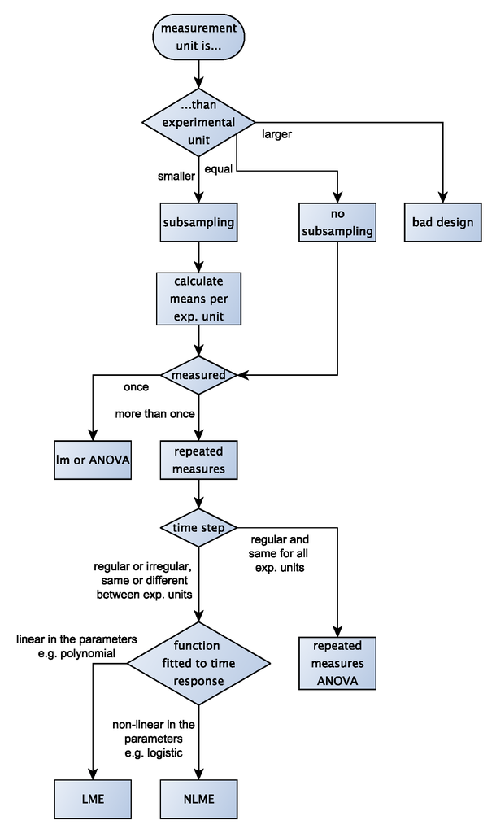

Measurement units and experimental units. The flowchart describes their possible nesting relationships and the corresponding matching statistical designs.

## 10.7 Pseudoreplication

Pseudoreplication involves the misidentification of the experimental unit as what is really the measurement unit, so giving a higher *n* than is truly the case. Examples of pseudoreplication are quite readily found in the scientific literature. In UV experiments pseudoreplication is particularly prevalent as researchers often mistake the plant for the lamp frame or filter as the experimental unit. Hurlbert (1984) was the first paper to bring this frequent problem of ecological research to light. Pseudoreplication is not just a small annoyance, it is a difficult problem in field experiments in ecology, and it frequently remains hidden within the Discussion and Conclusions sections of scientific papers. The most frequent scenario occurs when experiments are designed as a comparison of two *typical* experimental units but conclusions are applied to the whole population of units. In other words, conclusions are based on subsamples rather than on true replicates. Quinn and Keough (2002) describes this situation as a mismatch between the scale of treatments and the scale of replicates.

Pseudoreplication happens when subsamples are treated as replicates in the statistical analysis and interpretation.

When an experiment is thoughtfully planned and the researcher is certain about the identity the unit of replication, it should be possible to avoid pseudoreplication. However, where an oversight in planning or logistics has made pseudoreplication unavoidable, the additional assumptions involved in the interpretation of any statistical tests must be clearly indicated in reports or publications arising from the study. See Box [ex:stats:pseudo] for examples of pseudoreplication and suggested ways of avoiding this problem.

We want to study the effect of radiation on the growth of plants. We have two rooms, one with only normal lamps supplying PAR and one with some lamps in addition to the normal lamps. We randomly assign 20 plants to each room. We measure the height of the plants after one week. This experiment has 20 subsamples per treatment, but only one replicate. (The treatments were assigned at random to the rooms, not to the plants). It is not valid to treat the subsamples as replicates and try to draw conclusions about the effect of radiation, since we have only pseudoreplicates. In this case pseudoreplication adds the implicit **assumption** that the only difference between the rooms was the irradiance. Our statistical test really only answers the question: did the plants grow differently in the two rooms?

Several remedies are needed to obtain a wider range of validity from this experiment. Replicates in time can be created by repeating the experiment several times swapping the lamps between rooms. Such a situation is far from ideal because it is difficult to maintain plants and rooms in an equivalent state over time, since factors such as time of year and deterioration of lamps and filters must be accounted for. An additional step towards overcoming this problem would be to make a pre-experimental trial trying to create ‘identical’ conditions in both growth rooms and checking whether this results in any difference in plant performance.

We want to study the differences between high elevation and lowland meadow vegetation. We choose one typical lowland meadow (LM) and one high elevation meadow (HM). We establish 5 plots, located at random, within each meadow. In each plot we mark ten 1 m$^2$ sampling areas at random, and record the species composition within these areas.

It is not valid to try to answer the question ‘is species $x$ more frequent in lowland meadows than in highland meadows’ using the plots as replicates, since we have only pseudoreplication. The context of the question posed is critical in this instance. For this question we have, one true replicate (one meadow of each type), 5 subsamples (the plots) within each meadow, and 10 subsubsamples within each subsample. If the experiment is performed as described, it can only answer the question: “Is species $x$ more abundant in meadow ‘LM’ than meadow ‘HM’?” If we want to draw conclusions about the two (statistical) populations of meadows, we should sample at random from those populations. For example compare five different highland meadows to five lowland meadows.

We have three UV-B lamp frames. The radiation from the lamps in one frame is filtered with cellulose di-acetate, in another frame the lamps are filtered with polyester, and in the third frame the lamps are not energized. We chose at random three groups of 100 seedlings and put one group under each frame. This is an un-replicated experiment, we have one experimental unit (one lamp frame) per treatment. If we use the plants as replicates, we commit pseudoreplication. The plants are subsamples, not replicates.

Ideally we would try to obtain more lamp frames. If this was impossible, a replicated experiment could be created by sub-dividing the area under each lamp frame into two separate parts, and allocating one half of each containing 50 seedlings to be filtered by cellulose di-acetate and the other half by polyester. The unenergised lamp treatment would have to be omitted, but this compromise would enable three replicates of the two treatments to be created. Each lamp frame would be a block.

We have nine UV-B lamp frames, three for each treatment. We put 100 plants under each frame as above. We do the statistical analysis based on the measurements on each plant considering the plants as replicates, we commit pseudoreplication. Our estimate of the error variance is wrong, as it does not reflect the variation among frames with the same treatment, and degrees of freedom are hugely inflated.

Alternatively, we do the experiment exactly as in the item above, but we calculate means per frame for the measured variable, and then use these means in the statistical analysis. In other words we analyse our data using the frames as replicates. We have a valid test of significance, because the error variance reflects the variation between equally treated experimental units (the lamp frames). Logistical constraints often require that a decision must be made about whether to measure more plants under fewer replicates, or fewer plants under more replicates. When such a compromise has to be made, it is nearly always preferable to have more experimental units and to measure fewer plants within each one, even at the expense of greater allocation of time and resources to the maintenance of filters and lamp frames.

## 10.8 Range of validity

The range of validity of the conclusions of an experiment derives from the population upon which the experiment was performed. These conclusions can not be extrapolated beyond the statistical population from which the experimental units were randomly chosen. The wider the range of validity, the more generally applicable the information obtained from an experiment will be. If we wish to perform an experiment with broad applicability we can increase the breadth of the sampled population, but in doing so we run the risk of having more heterogeneous experimental units. This can make treatment effects more difficult to detect, unless we take special measures to control this error variation.

If we do an experiment with only one inbred variety of a crop species the results and conclusions will apply only to that variety. If we mix the seeds from several varieties and assign the plants at random to the treatments, we enlarge the range of validity of the results and conclusions but we increase the random variation. We can control for this increase in variation by using several varieties as blocks. In this way, we increase the range of validity of the results and conclusions without increasing the random variation.

The design of an experiment involves many compromises concerning its range of validity, these relate to trade-offs between generality, precision, and realism, not to mention cost.

### 10.8.1 Factorial experiments

One way of increasing the range of validity of the results of a scientific study is to use a factorial design for an experiment. For example, if we study the effects of radiation on well-watered plants only, then the conclusions of our study will be valid only for well-watered plants. If we include a second factor in our design with three levels, ‘drought’, ‘mild drought’ and ‘well watered’ and include all the treatment combinations possible, e.g. based on the three levels of watering and three levels of attenuation we have nine treatments and the range of validity is greatly expanded. In addition we can statistically test whether these two factors interact[^38]. Factorial experiments are a very powerful and useful design but if too many factors and levels are included their interpretation may become difficult. Factorial experiments with many factors and/or levels result in a statistical analysis based on many different contrasts[^39]. In this case, we should remember that in most analyzes we wish to obtain $P$-values per contrast, rather than per experiment. If we want to keep the experiment-wise risk level constant, we should use a tight contrast-wise risk level, or adjust the $P$-values.

The flowchart below describes the relationships between the structure of treatments and suitable methods for tests of significance.

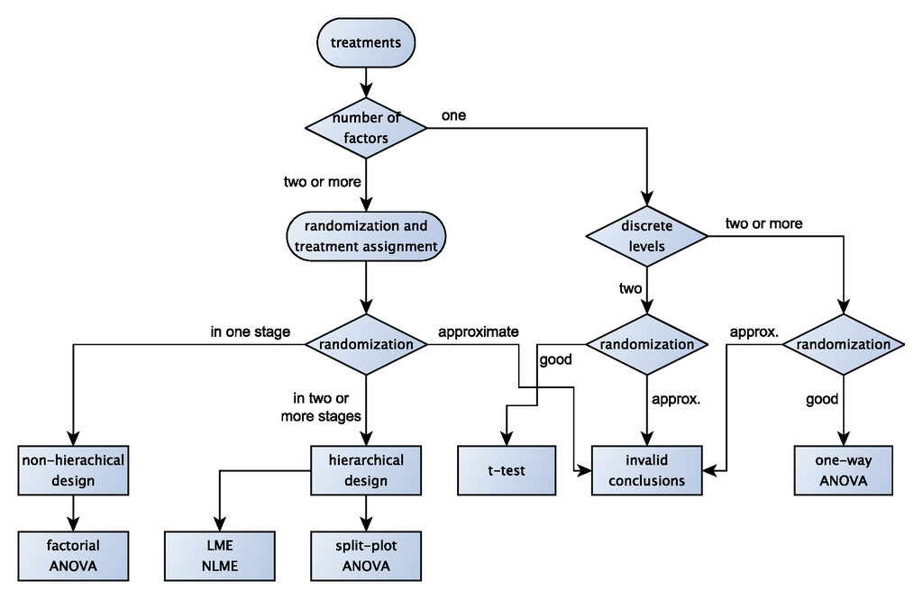

Choice of type of model fitting or statisitical test of significance based on the design of the experiment and approaches used for treatment assignment or randomization.

## 10.9 When not to make multiple comparisons

In the biological literature, multiple comparison procedures such as Tukey’s HSD are frequently used in situations where other tests would be more effective and easier to interpret. In some other cases multiple comparisons are used in situations in which they give misleading results. We will discuss the two most common cases of misuse of these tests.

### 10.9.1 Dose response curves

If we have several levels of the same treatment, for example several different irradiances of UV, the most powerful (capable of reliably detecting effects) test is to fit a regression (either linear or non-linear) of the response on the “dose”. From such an analysis we get information on the relationship between dose and response, whether it is increasing or decreasing, linear or curvilinear, even its shape can be inferred. In many cases we can also calculate a confidence band around the fitted function. This is all useful and interpretable information.

If instead we calculate for example HSD or LSD and compare the responses to all possible pairs of doses, we discard the information about the ordering of the doses, and we can get results that do not address our research hypothesis, for example, concluding that all pairs of adjacent doses do not differ significantly while the extreme doses do differ significantly. In this type of experiments we are really interested in the slope and shape of a dose response curve.

Multiple comparisons should be carried out only when there is no ordering in the levels of a treatment of factor. A regression or ANCOVA model should be used instead, if a reasonable model can be fitted.

### 10.9.2 Factorial experiments

Factorial experiments are very useful and as discussed above allow extending the range of validity of our conclusions. However, the main advantage of factorial experiments is that the significance of interactions can be tested. The most important part of the statistical analysis of a factorial experiment is an ANOVA with a model including main effects and interactions. Only after this test, one can *in addition*, test the differences among different pairs of treatments. This *a posteriori* test provides little extra information and should be done only if the interaction term is statistically significant. Otherwise, if the levels of a factor are discrete and unordered, and its main effect is significant in ANOVA, a multiple comparison test can be used to compare the levels of a factor (but not the individual combinations of levels of the different factors).

## 10.10 Presenting data in figures

When using hierarchical designs such as split-plots, the experimental errors relevant to comparisons between levels of the different factors will be different. In such designs, it is especially important to indicate which error term the error bars in figures show. In all cases, the figure and table legends should state which statistics are depicted by the error bars, and also the number of replicates involved in their calculation.

If what one wants to describe is the variability in the original sampled population then one should use the standard deviation (s.d.), whose expected value does not depend on the number of replicates. If one wants to compare treatment or group means, one should use confidence intervals (c.i.) or the standard error of the mean (s.e.). These last two statistics decrease in size with an increase in the number of replicates, reflecting increased reliability of the estimated means.

1. Avoid pseudoreplication. In most experiments where irradiance is manipulated either with lamps or filters, individual plants or pots are not true replicates. The true replicates are the lamp- or filter frames. Design your experiments and analyze your data taking this into account.
2. Avoid pseudoreplication. In experiments under controlled conditions, if treatments are assigned to chambers or rooms, these chambers or rooms are the true replicates, not the plants within them. To have true replicates you will need several rooms per treatment. When this is not possible, the experiment can be repeated in time, using the same chambers or rooms, but reassigning the treatments, so that each chamber is used for a different treatment in each iteration of the experiment.
3. Include enough true replicates in your experiment. Many effects of radiation are small in relation to the mean and subtle in comparison to natural levels of variability. Reliably detecting these effects requires well-replicated experiments.

   As a rough rule of thumb, aim at having at least 32 plants per treatment for growth, ecophysiology and metabolite measurements, in at least four true replicates composed each of eight measured plants in controlled environment and greenhouse studies. When making gas-exchange readings, it is usually impractical to measure from more than four to six plants in each of the four true replicates. If you aim to make an ecologically-orientated outdoor study it would be advisable to have at least five true replicates. In addition to issues of replication, in most cases you will need to have unmeasured border plants surrounding your experimental plants so as to avoid edge effects. Alternatively the positions of plants can be rotated every few days.
4. Preferably use a design with blocks to control all known or expected sources of error (or background variation) that would otherwise confound the treatment effects. Examples of such sources of variation are different benches in a greenhouse, or measurements done by different observers. If you suspect that a known source of error may interact with your UV treatment, you may decide to consider it as a covariate in your model.
5. Within the blocks, use randomization to neutralize the effects of other error sources. Randomization is of fundamental importance and should be done properly: i.e. a device that generates a truly random assignment of treatments to experimental units should be employed. Such devices can be as simple as a coin, or die, or can be a table of random numbers in a book, or (pseudo-) random numbers generated by a computer or a pocket calculator.
6. When designing an experiment use power analysis to determine the number of replicates needed, unless you have a long experience of performing similar experiments, and a good existing understanding of the amount of variability you expect to find in your results.
7. If your experiment yields a non-significant difference, use *a posteriori* power analysis to demonstrate, if possible, that biologically important differences would have been detected had they existed. However, if power analysis reveals that your experiment was unable to detect biologically important differences, you should repeat the experiment with more replicates or an improved design.

## 10.12 Further reading

A reliable on-line resource is the *Statistics Stack Exchange* (http://stats.stackexchange.com/).

There are many text books on statistics, but most introductory statistical texts do not discuss the type of hierarchical models usually needed for experiments. We recommend the classic book ‘Planning of Experiments’ by Cox (1958) as a good introduction to the principles behind the design of experiments. ‘Experimental Design and Data Analysis for Biologists’ by Quinn and Keough (2002) describes both experimental design and analysis of data at an intermediate level. The books ‘Ecological Models and Data in R’ (Bolker 2008) and ‘Mixed effects models and extensions in ecology with R’ (Zuur, Ieno, Walker, et al. 2009) give advanced up-to-date accounts of statistical methods, and approaches, including a discussion of hypothesis testing and model fitting. While ‘A Beginner’s Guide to R’ (Zuur, Ieno, and Meesters 2009) and ‘Introductory Statistics with R’ (Dalgaard 2002) are gentle introductions to data analysis with R.

Bolker, Benjamin M. 2008. *Ecological Models and Data in r*. Princeton University Press.

Cochran, W. G. 1957. “Analysis of Covariance Its Nature and Uses.” *Biometrics* 13: 261–81. http://www.jstor.org/stable/2527916.

Cohen, J. 1977. *Statistical Power Analysis for the Behavioral Sciences*. Revised edition. Academic Press.

Cox, D. R. 1958. *Planning of Experiments*. John Wiley & Sons.

Cox, D. R., and Nancy Reid. 2000. *The Theory of the Design of Experiments*. 1st ed. Chapman; Hall/CRC.

Dalgaard, P. 2002. *Introductory Statistics with r*. Statistics and Computing. Springer.

Efron, Bradley. 2020. “Prediction, Estimation, and Attribution.” *Journal of the American Statistical Association* 115 (530): 636–55. https://doi.org/10.1080/01621459.2020.1762613.

Hurlbert, S. H. 1984. “Pseudoreplication and the Design of Ecological Field Experiments.” *Ecological Monographs* 54 (2): 187–211. https://doi.org/10.2307/1942661.

Quinn, G. P., and M. J. Keough. 2002. *Experimental Design and Data Analysis for Biologists*. Cambridge University Press.

Smith, H. F. 1957. “Interpretation of Adjusted Treatment Means and Regressions in Analysis of Covariance.” *Biometrics* 13: 281–308. http://www.jstor.org/stable/2527917.

Tukey, John W. 1991. “The Philosophy of Multiple Comparisons.” *Statistical Science* 6 (1): 100–116. https://doi.org/10.1214/ss/1177011945.

Zuur, Alain F., Elena N. Ieno, and Erik Meesters. 2009. *A Beginner’s Guide to R*. Springer.

Zuur, Alain F., Elena N. Ieno, Neil Walker, Anatoly A. Saveliev, and Graham M. Smith. 2009. *Mixed Effects Models and Extensions in Ecology with r*. Springer.